# Potential Correlations between Risk behaviors and Cervical Cancer

**For this project, I want to test my hypothesis that there exists some kind of correlations between risk behaviors and Cervical Cancer. I used 2 datasets from UCI Machine Learning repository: Cervical cancer (Risk Factors) Data Set (long_df, which contains 858 intances with 36 attributes) and Cervical Cancer Behavior Risk Data Set (short_df, which contains 72 instances with 19 attributes and no NaN values).**

**For the long_df, I dropped instances containing "?" value and cropped it down to a smaller number of attributes, which I decided to be helpful in deriving conclusion. The short_df doesn't have NaN values so I just had to choose the useful attributes.**

**I used pandas to read the datasets in as dataframes, matplotlib and seaborn to create plots like distplot, pairplot heatmap and clustermap, as well as looking for correlations between attributes.**

### First of all, let's import all the dependencies and load our datasets

```python
import pandas as pd
import matplotlib.pyplot as plt
import seaborn as sns
sns.set_style('whitegrid')
%matplotlib inline

long_df = pd.read_csv("risk_factors_cervical_cancer.csv")
short_df = pd.read_csv("sobar-72.csv")

print(short_df.shape)
```

```
(72, 20)
```

```python
print(long_df.shape)
```

```
(858, 36)
```

### Let's take an overview at the datasets

```python
long_df.info()
```

```
<class 'pandas.core.frame.DataFrame'>
RangeIndex: 858 entries, 0 to 857
Data columns (total 36 columns):
Age                                   858 non-null int64
Number of sexual partners             858 non-null object
First sexual intercourse              858 non-null object
Num of pregnancies                    858 non-null object
Smokes                                858 non-null object
Smokes (years)                        858 non-null object
Smokes (packs/year)                   858 non-null object
Hormonal Contraceptives               858 non-null object
Hormonal Contraceptives (years)       858 non-null object
IUD                                   858 non-null object
IUD (years)                           858 non-null object
STDs                                  858 non-null object
STDs (number)                         858 non-null object
STDs:condylomatosis                   858 non-null object
STDs:cervical condylomatosis          858 non-null object
STDs:vaginal condylomatosis           858 non-null object
STDs:vulvo-perineal condylomatosis    858 non-null object
STDs:syphilis                         858 non-null object
STDs:pelvic inflammatory disease      858 non-null object
STDs:genital herpes                   858 non-null object
STDs:molluscum contagiosum            858 non-null object
STDs:AIDS                             858 non-null object
STDs:HIV                              858 non-null object
STDs:Hepatitis B                      858 non-null object
STDs:HPV                              858 non-null object
STDs: Number of diagnosis             858 non-null int64
STDs: Time since first diagnosis      858 non-null object
STDs: Time since last diagnosis       858 non-null object
Dx:Cancer                             858 non-null int64
Dx:CIN                                858 non-null int64
Dx:HPV                                858 non-null int64
Dx                                    858 non-null int64
Hinselmann                            858 non-null int64
Schiller                              858 non-null int64
Citology                              858 non-null int64
Biopsy                                858 non-null int64
dtypes: int64(10), object(26)
memory usage: 241.4+ KB
```

**The long_df has 858 entries with 36 attributes. Most attributes are named in a meaningful way; however, some of them are a bit confusing for people who have little medical knowledge. For example, Dx is a boolean representing if the patient has Cervical Cancer, and Dx:Cancer is also a boolean representing if the patient has other types of cancer. Hinselmann, Schiller, Citology and Biopsy are tests used to diagnose Cervical cancer.**

```python
short_df.info()
```

```
<class 'pandas.core.frame.DataFrame'>
RangeIndex: 72 entries, 0 to 71
Data columns (total 20 columns):
behavior_sexualRisk           72 non-null int64
behavior_eating               72 non-null int64
behavior_personalHygine       72 non-null int64
intention_aggregation         72 non-null int64
intention_commitment          72 non-null int64
attitude_consistency          72 non-null int64
attitude_spontaneity          72 non-null int64
norm_significantPerson        72 non-null int64
norm_fulfillment              72 non-null int64
perception_vulnerability      72 non-null int64
perception_severity           72 non-null int64
motivation_strength           72 non-null int64
motivation_willingness        72 non-null int64
socialSupport_emotionality    72 non-null int64
socialSupport_appreciation    72 non-null int64
socialSupport_instrumental    72 non-null int64
empowerment_knowledge         72 non-null int64
empowerment_abilities         72 non-null int64
empowerment_desires           72 non-null int64
ca_cervix                     72 non-null int64
dtypes: int64(20)
memory usage: 11.3 KB
```

**The short_df is more well defined and cleaner. It has 72 entries with 19 attributes. The attributes are grouped in common categories, which makes it easier to compare and contrast. This is a short dataset but very interesting and informative.**

### And get some basic statistics

```python
long_df.describe()
```

|  | Age | STDs: Number of diagnosis | Dx:Cancer | Dx:CIN | Dx:HPV | Dx | Hinselmann | Schiller | Citology | Biopsy |
| --- | --- | --- | --- | --- | --- | --- | --- | --- | --- | --- |
| count | 858.000000 | 858.000000 | 858.000000 | 858.000000 | 858.000000 | 858.000000 | 858.000000 | 858.000000 | 858.000000 | 858.000000 |
| mean | 26.820513 | 0.087413 | 0.020979 | 0.010490 | 0.020979 | 0.027972 | 0.040793 | 0.086247 | 0.051282 | 0.064103 |
| std | 8.497948 | 0.302545 | 0.143398 | 0.101939 | 0.143398 | 0.164989 | 0.197925 | 0.280892 | 0.220701 | 0.245078 |
| min | 13.000000 | 0.000000 | 0.000000 | 0.000000 | 0.000000 | 0.000000 | 0.000000 | 0.000000 | 0.000000 | 0.000000 |
| 25% | 20.000000 | 0.000000 | 0.000000 | 0.000000 | 0.000000 | 0.000000 | 0.000000 | 0.000000 | 0.000000 | 0.000000 |
| 50% | 25.000000 | 0.000000 | 0.000000 | 0.000000 | 0.000000 | 0.000000 | 0.000000 | 0.000000 | 0.000000 | 0.000000 |
| 75% | 32.000000 | 0.000000 | 0.000000 | 0.000000 | 0.000000 | 0.000000 | 0.000000 | 0.000000 | 0.000000 | 0.000000 |
| max | 84.000000 | 3.000000 | 1.000000 | 1.000000 | 1.000000 | 1.000000 | 1.000000 | 1.000000 | 1.000000 | 1.000000 |

```python
short_df.describe()
```

|  | behavior_sexualRisk | behavior_eating | behavior_personalHygine | intention_aggregation | intention_commitment | attitude_consistency | attitude_spontaneity | norm_significantPerson | norm_fulfillment | perception_vulnerability | perception_severity | motivation_strength | motivation_willingness | socialSupport_emotionality | socialSupport_appreciation | socialSupport_instrumental | empowerment_knowledge | empowerment_abilities | empowerment_desires | ca_cervix |
| --- | --- | --- | --- | --- | --- | --- | --- | --- | --- | --- | --- | --- | --- | --- | --- | --- | --- | --- | --- | --- |
| count | 72.000000 | 72.000000 | 72.000000 | 72.000000 | 72.000000 | 72.000000 | 72.000000 | 72.000000 | 72.000000 | 72.000000 | 72.000000 | 72.000000 | 72.000000 | 72.000000 | 72.000000 | 72.000000 | 72.000000 | 72.000000 | 72.000000 | 72.000000 |
| mean | 9.666667 | 12.791667 | 11.083333 | 7.902778 | 13.347222 | 7.180556 | 8.611111 | 3.125000 | 8.486111 | 8.513889 | 5.388889 | 12.652778 | 9.694444 | 8.097222 | 6.166667 | 10.375000 | 10.541667 | 9.319444 | 10.277778 | 0.291667 |
| std | 1.186782 | 2.361293 | 3.033847 | 2.738148 | 2.374511 | 1.522844 | 1.515698 | 1.845722 | 4.907577 | 4.275686 | 3.400727 | 3.207209 | 4.130406 | 4.243171 | 2.897303 | 4.316485 | 4.366768 | 4.181874 | 4.482273 | 0.457719 |
| min | 2.000000 | 3.000000 | 3.000000 | 2.000000 | 6.000000 | 2.000000 | 4.000000 | 1.000000 | 3.000000 | 3.000000 | 2.000000 | 3.000000 | 3.000000 | 3.000000 | 2.000000 | 3.000000 | 3.000000 | 3.000000 | 3.000000 | 0.000000 |
| 25% | 10.000000 | 11.000000 | 9.000000 | 6.000000 | 11.000000 | 6.000000 | 8.000000 | 1.000000 | 3.000000 | 5.000000 | 2.000000 | 11.000000 | 7.000000 | 3.000000 | 3.750000 | 6.750000 | 7.000000 | 5.000000 | 6.750000 | 0.000000 |
| 50% | 10.000000 | 13.000000 | 11.000000 | 10.000000 | 15.000000 | 7.000000 | 9.000000 | 3.000000 | 7.000000 | 8.000000 | 4.000000 | 14.000000 | 11.000000 | 9.000000 | 6.500000 | 12.000000 | 12.000000 | 10.000000 | 11.000000 | 0.000000 |
| 75% | 10.000000 | 15.000000 | 14.000000 | 10.000000 | 15.000000 | 8.000000 | 10.000000 | 5.000000 | 14.000000 | 13.000000 | 9.000000 | 15.000000 | 13.000000 | 11.250000 | 9.000000 | 14.250000 | 15.000000 | 13.000000 | 15.000000 | 1.000000 |
| max | 10.000000 | 15.000000 | 15.000000 | 10.000000 | 15.000000 | 10.000000 | 10.000000 | 5.000000 | 15.000000 | 15.000000 | 10.000000 | 15.000000 | 15.000000 | 15.000000 | 10.000000 | 15.000000 | 15.000000 | 15.000000 | 15.000000 | 1.000000 |

### Check out the first few lines

```python
long_df.head()
```

|  | Age | Number of sexual partners | First sexual intercourse | Num of pregnancies | Smokes | Smokes (years) | Smokes (packs/year) | Hormonal Contraceptives | Hormonal Contraceptives (years) | IUD | ... | STDs: Time since first diagnosis | STDs: Time since last diagnosis | Dx:Cancer | Dx:CIN | Dx:HPV | Dx | Hinselmann | Schiller | Citology | Biopsy |
| --- | --- | --- | --- | --- | --- | --- | --- | --- | --- | --- | --- | --- | --- | --- | --- | --- | --- | --- | --- | --- | --- |
| 0 | 18 | 4.0 | 15.0 | 1.0 | 0.0 | 0.0 | 0.0 | 0.0 | 0.0 | 0.0 | ... | ? | ? | 0 | 0 | 0 | 0 | 0 | 0 | 0 | 0 |
| 1 | 15 | 1.0 | 14.0 | 1.0 | 0.0 | 0.0 | 0.0 | 0.0 | 0.0 | 0.0 | ... | ? | ? | 0 | 0 | 0 | 0 | 0 | 0 | 0 | 0 |
| 2 | 34 | 1.0 | ? | 1.0 | 0.0 | 0.0 | 0.0 | 0.0 | 0.0 | 0.0 | ... | ? | ? | 0 | 0 | 0 | 0 | 0 | 0 | 0 | 0 |
| 3 | 52 | 5.0 | 16.0 | 4.0 | 1.0 | 37.0 | 37.0 | 1.0 | 3.0 | 0.0 | ... | ? | ? | 1 | 0 | 1 | 0 | 0 | 0 | 0 | 0 |
| 4 | 46 | 3.0 | 21.0 | 4.0 | 0.0 | 0.0 | 0.0 | 1.0 | 15.0 | 0.0 | ... | ? | ? | 0 | 0 | 0 | 0 | 0 | 0 | 0 | 0 |

5 rows × 36 columns

```python
short_df.head()
```

|  | behavior_sexualRisk | behavior_eating | behavior_personalHygine | intention_aggregation | intention_commitment | attitude_consistency | attitude_spontaneity | norm_significantPerson | norm_fulfillment | perception_vulnerability | perception_severity | motivation_strength | motivation_willingness | socialSupport_emotionality | socialSupport_appreciation | socialSupport_instrumental | empowerment_knowledge | empowerment_abilities | empowerment_desires | ca_cervix |
| --- | --- | --- | --- | --- | --- | --- | --- | --- | --- | --- | --- | --- | --- | --- | --- | --- | --- | --- | --- | --- |
| 0 | 10 | 13 | 12 | 4 | 7 | 9 | 10 | 1 | 8 | 7 | 3 | 14 | 8 | 5 | 7 | 12 | 12 | 11 | 8 | 1 |
| 1 | 10 | 11 | 11 | 10 | 14 | 7 | 7 | 5 | 5 | 4 | 2 | 15 | 13 | 7 | 6 | 5 | 5 | 4 | 4 | 1 |
| 2 | 10 | 15 | 3 | 2 | 14 | 8 | 10 | 1 | 4 | 7 | 2 | 7 | 3 | 3 | 6 | 11 | 3 | 3 | 15 | 1 |
| 3 | 10 | 11 | 10 | 10 | 15 | 7 | 7 | 1 | 5 | 4 | 2 | 15 | 13 | 7 | 4 | 4 | 4 | 4 | 4 | 1 |
| 4 | 8 | 11 | 7 | 8 | 10 | 7 | 8 | 1 | 5 | 3 | 2 | 15 | 5 | 3 | 6 | 12 | 5 | 4 | 7 | 1 |

### The long dataset has many NaN values (which in this case is "?") that need to be cleaned.

```python
(long_df == "?").any()
```

```
Age                                   False
Number of sexual partners              True
First sexual intercourse               True
Num of pregnancies                     True
Smokes                                 True
Smokes (years)                         True
Smokes (packs/year)                    True
Hormonal Contraceptives                True
Hormonal Contraceptives (years)        True
IUD                                    True
IUD (years)                            True
STDs                                   True
STDs (number)                          True
STDs:condylomatosis                    True
STDs:cervical condylomatosis           True
STDs:vaginal condylomatosis            True
STDs:vulvo-perineal condylomatosis     True
STDs:syphilis                          True
STDs:pelvic inflammatory disease       True
STDs:genital herpes                    True
STDs:molluscum contagiosum             True
STDs:AIDS                              True
STDs:HIV                               True
STDs:Hepatitis B                       True
STDs:HPV                               True
STDs: Number of diagnosis             False
STDs: Time since first diagnosis       True
STDs: Time since last diagnosis        True
Dx:Cancer                             False
Dx:CIN                                False
Dx:HPV                                False
Dx                                    False
Hinselmann                            False
Schiller                              False
Citology                              False
Biopsy                                False
dtype: bool
```

### Decide on what features are useful to reach the desired output

```python
#extracting valuable information (columns) for the project
smoke_data = long_df[['Age','Number of sexual partners','First sexual intercourse','Num of pregnancies','Smokes','Smokes (years)',\
             'Smokes (packs/year)','Dx:Cancer','Dx:CIN','Dx:HPV','Dx','Hinselmann','Schiller','Citology','Biopsy']]
```

```python
smoke_data.columns
```

```
Index(['Age', 'Number of sexual partners', 'First sexual intercourse',
       'Num of pregnancies', 'Smokes', 'Smokes (years)', 'Smokes (packs/year)',
       'Dx:Cancer', 'Dx:CIN', 'Dx:HPV', 'Dx', 'Hinselmann', 'Schiller',
       'Citology', 'Biopsy'],
      dtype='object')
```

### We notice that the long_df has null values which is in the form of "?". Let's clean it.

```python
#dropping NaN entries (ones with "?")
smoke_data = smoke_data[smoke_data['Smokes'] != '?']
smoke_data = smoke_data[smoke_data['Num of pregnancies'] != '?']
smoke_data = smoke_data[smoke_data['Number of sexual partners'] != '?']
smoke_data = smoke_data[smoke_data['First sexual intercourse'] != '?']
```

### We cut down a few rows, not so many that would affect the outcome

```python
len(smoke_data)
```

```
761
```

### Check if there are any null left. Looks like we're good to proceed

```python
(smoke_data == "?").any()
```

```
Age                          False
Number of sexual partners    False
First sexual intercourse     False
Num of pregnancies           False
Smokes                       False
Smokes (years)               False
Smokes (packs/year)          False
Dx:Cancer                    False
Dx:CIN                       False
Dx:HPV                       False
Dx                           False
Hinselmann                   False
Schiller                     False
Citology                     False
Biopsy                       False
dtype: bool
```

### Create a pairplot to see correlations among attributes in smoke_data

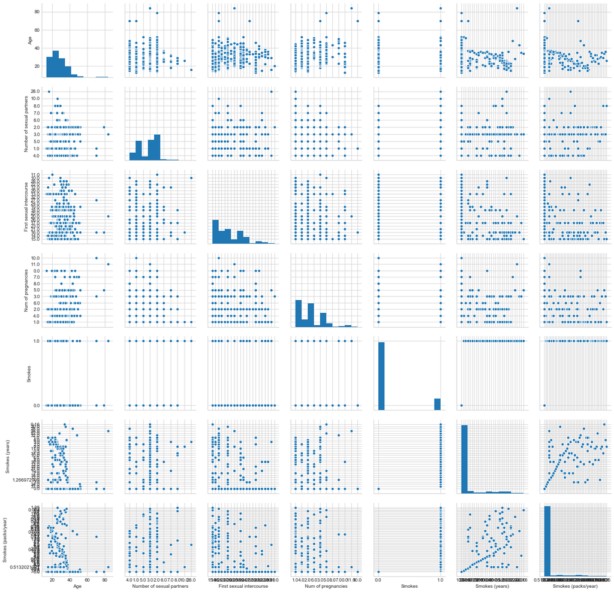

```python
sns.pairplot(smoke_data[['Age','Number of sexual partners','First sexual intercourse','Num of pregnancies',\
                        'Smokes','Smokes (years)','Smokes (packs/year)']])
```

### There is a positive linear relationship between the number of years smoking and the number of packs smoked. Most heavy smokers are younger than 40.

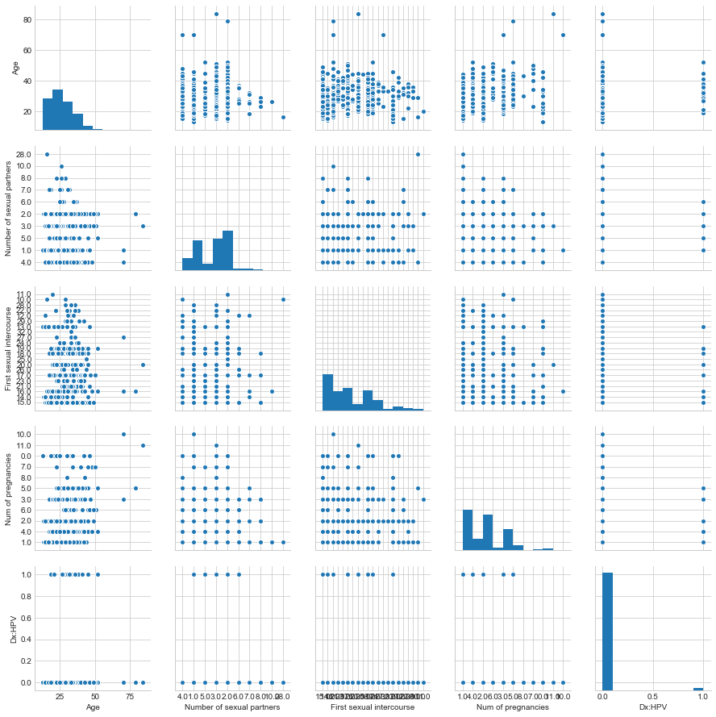

```python
sns.pairplot(smoke_data[['Age','Number of sexual partners','First sexual intercourse','Num of pregnancies',\
                        'Dx:HPV']])
```

### And make a histogram for the age to see if it's normally distrubuted.

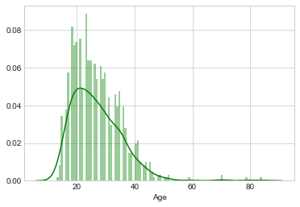

```python
age = long_df['Age']
sns.distplot(age, color ='green',bins=100)
```

### It is commonly known that cervical cancer tends to occur in older age women. However, this plot shows us most people in this dataset are in their twenties. The curve is skewed to the right.

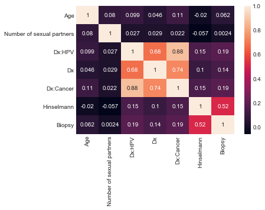

```python
sns.heatmap(smoke_data[['Age','Number of sexual partners','Dx:HPV','Dx','Dx:Cancer', 'Hinselmann', 'Biopsy']].corr(),annot=True)
```

### However, there is a strong correlation between having HPV and having another type of cancer (0.88).

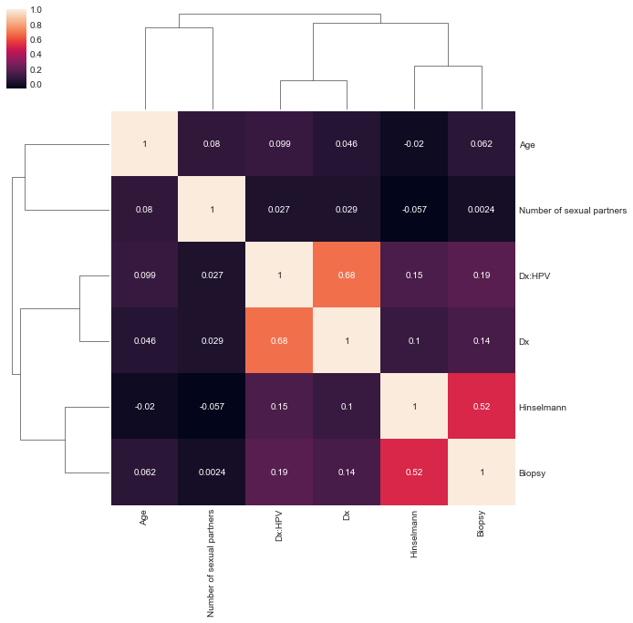

```python
sns.clustermap(smoke_data[['Age','Number of sexual partners','Dx:HPV','Dx', 'Hinselmann', 'Biopsy']].corr(),annot=True)
```

### Below is a heatmap from the short_df with correlations among behavior_sexualRisk, behavior_eating and behavior_personalHygine, which doesn't appear to have clear correlations.

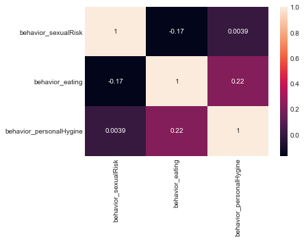

```python
sns.heatmap(short_df[['behavior_sexualRisk','behavior_eating','behavior_personalHygine']].corr(),annot=True)
```

### Next, a clustermap for the 7 attributes in the short_df.

### We notice a strong correlation between empowerment_knowledge and empowerment_abilities, which is 0.84 as well as moderate correlations between empowerment_abilities and socialSupport_emotionality: 0.78, socialSupport_appreciation and socialSupport_instrumental: 0.74.

### There exists moderate correlations between Cervical Cancer and some attributes.

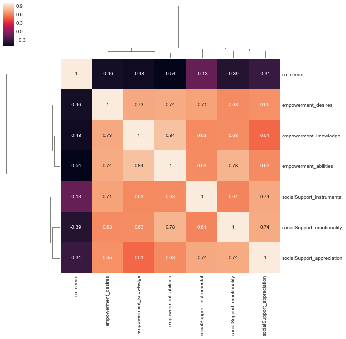

```python
sns.clustermap(short_df[['socialSupport_emotionality','socialSupport_appreciation','socialSupport_instrumental',\
                      'empowerment_knowledge','empowerment_abilities','empowerment_desires','ca_cervix']].corr(),annot=True)
```

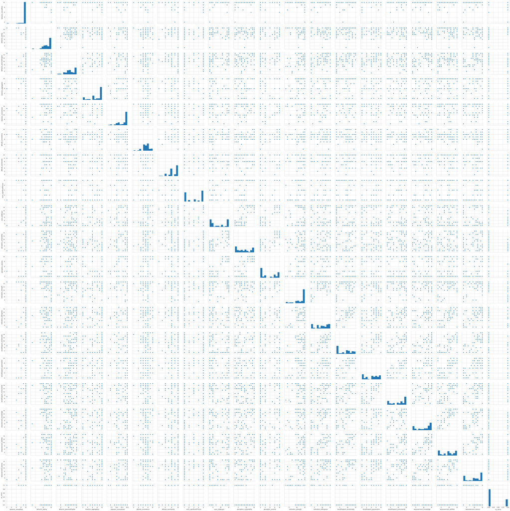

```python
sns.pairplot(short_df)
```

### In the short_df, there are 21 out of 72 entries that have Cervical Cancer

```python
short_df[short_df['ca_cervix']==1]
```

|  | behavior_sexualRisk | behavior_eating | behavior_personalHygine | intention_aggregation | intention_commitment | attitude_consistency | attitude_spontaneity | norm_significantPerson | norm_fulfillment | perception_vulnerability | perception_severity | motivation_strength | motivation_willingness | socialSupport_emotionality | socialSupport_appreciation | socialSupport_instrumental | empowerment_knowledge | empowerment_abilities | empowerment_desires | ca_cervix |
| --- | --- | --- | --- | --- | --- | --- | --- | --- | --- | --- | --- | --- | --- | --- | --- | --- | --- | --- | --- | --- |
| 0 | 10 | 13 | 12 | 4 | 7 | 9 | 10 | 1 | 8 | 7 | 3 | 14 | 8 | 5 | 7 | 12 | 12 | 11 | 8 | 1 |
| 1 | 10 | 11 | 11 | 10 | 14 | 7 | 7 | 5 | 5 | 4 | 2 | 15 | 13 | 7 | 6 | 5 | 5 | 4 | 4 | 1 |
| 2 | 10 | 15 | 3 | 2 | 14 | 8 | 10 | 1 | 4 | 7 | 2 | 7 | 3 | 3 | 6 | 11 | 3 | 3 | 15 | 1 |
| 3 | 10 | 11 | 10 | 10 | 15 | 7 | 7 | 1 | 5 | 4 | 2 | 15 | 13 | 7 | 4 | 4 | 4 | 4 | 4 | 1 |
| 4 | 8 | 11 | 7 | 8 | 10 | 7 | 8 | 1 | 5 | 3 | 2 | 15 | 5 | 3 | 6 | 12 | 5 | 4 | 7 | 1 |
| 5 | 10 | 14 | 8 | 6 | 15 | 8 | 10 | 1 | 3 | 4 | 2 | 14 | 8 | 7 | 2 | 7 | 13 | 9 | 6 | 1 |
| 6 | 10 | 15 | 4 | 6 | 14 | 6 | 10 | 5 | 3 | 7 | 2 | 7 | 13 | 3 | 3 | 15 | 3 | 3 | 5 | 1 |
| 7 | 8 | 12 | 9 | 10 | 10 | 5 | 10 | 5 | 5 | 5 | 2 | 10 | 9 | 13 | 2 | 9 | 8 | 7 | 12 | 1 |
| 8 | 10 | 15 | 7 | 2 | 15 | 6 | 10 | 1 | 3 | 5 | 2 | 9 | 15 | 13 | 10 | 15 | 13 | 15 | 15 | 1 |
| 9 | 7 | 15 | 7 | 6 | 11 | 8 | 8 | 5 | 3 | 3 | 4 | 15 | 3 | 8 | 2 | 9 | 3 | 4 | 4 | 1 |
| 10 | 7 | 15 | 7 | 10 | 14 | 7 | 9 | 1 | 3 | 8 | 2 | 4 | 3 | 7 | 9 | 13 | 8 | 3 | 9 | 1 |
| 11 | 10 | 15 | 8 | 9 | 15 | 7 | 10 | 1 | 3 | 7 | 2 | 15 | 3 | 3 | 6 | 13 | 7 | 5 | 9 | 1 |
| 12 | 10 | 15 | 12 | 10 | 15 | 6 | 10 | 1 | 3 | 3 | 2 | 4 | 3 | 3 | 2 | 15 | 13 | 6 | 11 | 1 |
| 13 | 9 | 12 | 14 | 9 | 15 | 10 | 9 | 3 | 6 | 3 | 2 | 15 | 15 | 3 | 10 | 15 | 11 | 3 | 11 | 1 |
| 14 | 2 | 15 | 15 | 6 | 13 | 8 | 9 | 1 | 3 | 3 | 4 | 15 | 3 | 7 | 6 | 7 | 7 | 7 | 3 | 1 |
| 15 | 10 | 15 | 7 | 6 | 14 | 8 | 8 | 4 | 8 | 10 | 2 | 3 | 3 | 3 | 2 | 5 | 5 | 5 | 3 | 1 |
| 16 | 10 | 15 | 9 | 7 | 6 | 8 | 8 | 1 | 12 | 5 | 4 | 5 | 4 | 3 | 3 | 5 | 7 | 7 | 3 | 1 |
| 17 | 10 | 12 | 7 | 5 | 10 | 8 | 8 | 1 | 8 | 10 | 4 | 6 | 3 | 3 | 2 | 4 | 4 | 3 | 5 | 1 |
| 18 | 10 | 11 | 12 | 2 | 10 | 8 | 8 | 2 | 10 | 8 | 7 | 6 | 5 | 3 | 2 | 4 | 4 | 4 | 3 | 1 |
| 19 | 10 | 12 | 12 | 8 | 10 | 8 | 6 | 2 | 7 | 6 | 2 | 12 | 11 | 9 | 8 | 12 | 10 | 10 | 9 | 1 |
| 20 | 10 | 15 | 15 | 4 | 15 | 8 | 10 | 5 | 3 | 8 | 3 | 11 | 3 | 3 | 2 | 7 | 8 | 5 | 3 | 1 |

```python
long_df.columns
```

```
Index(['Age', 'Number of sexual partners', 'First sexual intercourse',
       'Num of pregnancies', 'Smokes', 'Smokes (years)', 'Smokes (packs/year)',
       'Hormonal Contraceptives', 'Hormonal Contraceptives (years)', 'IUD',
       'IUD (years)', 'STDs', 'STDs (number)', 'STDs:condylomatosis',
       'STDs:cervical condylomatosis', 'STDs:vaginal condylomatosis',
       'STDs:vulvo-perineal condylomatosis', 'STDs:syphilis',
       'STDs:pelvic inflammatory disease', 'STDs:genital herpes',
       'STDs:molluscum contagiosum', 'STDs:AIDS', 'STDs:HIV',
       'STDs:Hepatitis B', 'STDs:HPV', 'STDs: Number of diagnosis',
       'STDs: Time since first diagnosis', 'STDs: Time since last diagnosis',
       'Dx:Cancer', 'Dx:CIN', 'Dx:HPV', 'Dx', 'Hinselmann', 'Schiller',
       'Citology', 'Biopsy'],
      dtype='object')
```

```python
age = long_df['Age']
age_with_other_cancer = long_df['Dx:Cancer']
age_with_other_cancer = long_df[long_df['Dx:Cancer']==1]['Age']
```

### Age of people who have other kinds of cancer

```python
age_with_other_cancer
#(age.isna() == False).count
```

```
3      52
8      45
23     40
64     38
188    27
335    29
432    31
578    19
610    21
669    38
727    31
738    27
763    41
775    27
797    33
822    36
839    31
849    32
Name: Age, dtype: int64
```

```python
has_cancer = long_df['Dx']
age_with_cancer = long_df[long_df['Dx']==1]['Age']
age_with_cancer
```

```
8      45
41     37
109    32
188    27
197    26
229    27
335    29
432    31
578    19
610    21
652    59
653    21
654    45
655    21
669    38
727    31
738    27
763    41
765    25
769    26
775    27
797    33
822    36
839    31
Name: Age, dtype: int64
```

### And age of people who have Cervical Cancer in the long_df

```python
len(age_with_cancer)
```

```
24
```

```python
long_df.loc[:, ~(long_df == '?').any()]
```

|  | Age | STDs: Number of diagnosis | Dx:Cancer | Dx:CIN | Dx:HPV | Dx | Hinselmann | Schiller | Citology | Biopsy |
| --- | --- | --- | --- | --- | --- | --- | --- | --- | --- | --- |
| 0 | 18 | 0 | 0 | 0 | 0 | 0 | 0 | 0 | 0 | 0 |
| 1 | 15 | 0 | 0 | 0 | 0 | 0 | 0 | 0 | 0 | 0 |
| 2 | 34 | 0 | 0 | 0 | 0 | 0 | 0 | 0 | 0 | 0 |
| 3 | 52 | 0 | 1 | 0 | 1 | 0 | 0 | 0 | 0 | 0 |
| 4 | 46 | 0 | 0 | 0 | 0 | 0 | 0 | 0 | 0 | 0 |
| 5 | 42 | 0 | 0 | 0 | 0 | 0 | 0 | 0 | 0 | 0 |
| 6 | 51 | 0 | 0 | 0 | 0 | 0 | 1 | 1 | 0 | 1 |
| 7 | 26 | 0 | 0 | 0 | 0 | 0 | 0 | 0 | 0 | 0 |
| 8 | 45 | 0 | 1 | 0 | 1 | 1 | 0 | 0 | 0 | 0 |
| 9 | 44 | 0 | 0 | 0 | 0 | 0 | 0 | 0 | 0 | 0 |
| 10 | 44 | 0 | 0 | 0 | 0 | 0 | 0 | 0 | 0 | 0 |
| 11 | 27 | 0 | 0 | 0 | 0 | 0 | 0 | 0 | 0 | 0 |
| 12 | 45 | 0 | 0 | 0 | 0 | 0 | 0 | 0 | 0 | 0 |
| 13 | 44 | 0 | 0 | 0 | 0 | 0 | 0 | 0 | 0 | 0 |
| 14 | 43 | 0 | 0 | 0 | 0 | 0 | 0 | 0 | 0 | 0 |
| 15 | 40 | 0 | 0 | 0 | 0 | 0 | 0 | 0 | 0 | 0 |
| 16 | 41 | 0 | 0 | 0 | 0 | 0 | 0 | 0 | 0 | 0 |
| 17 | 43 | 0 | 0 | 0 | 0 | 0 | 0 | 0 | 0 | 0 |
| 18 | 42 | 0 | 0 | 0 | 0 | 0 | 0 | 0 | 0 | 0 |
| 19 | 40 | 0 | 0 | 0 | 0 | 0 | 0 | 0 | 0 | 0 |
| 20 | 43 | 0 | 0 | 0 | 0 | 0 | 0 | 0 | 0 | 0 |
| 21 | 41 | 1 | 0 | 0 | 0 | 0 | 0 | 0 | 0 | 0 |
| 22 | 40 | 1 | 0 | 0 | 0 | 0 | 0 | 1 | 1 | 1 |
| 23 | 40 | 0 | 1 | 0 | 1 | 0 | 1 | 1 | 0 | 1 |
| 24 | 40 | 0 | 0 | 0 | 0 | 0 | 0 | 0 | 0 | 0 |
| 25 | 44 | 0 | 0 | 0 | 0 | 0 | 0 | 0 | 0 | 0 |
| 26 | 39 | 0 | 0 | 0 | 0 | 0 | 0 | 0 | 0 | 0 |
| 27 | 39 | 0 | 0 | 0 | 0 | 0 | 0 | 0 | 0 | 0 |
| 28 | 37 | 0 | 0 | 0 | 0 | 0 | 0 | 0 | 0 | 0 |
| 29 | 37 | 0 | 0 | 0 | 0 | 0 | 0 | 0 | 0 | 0 |
| ... | ... | ... | ... | ... | ... | ... | ... | ... | ... | ... |
| 828 | 33 | 0 | 0 | 0 | 0 | 0 | 0 | 0 | 0 | 0 |
| 829 | 34 | 0 | 0 | 0 | 0 | 0 | 0 | 0 | 0 | 0 |
| 830 | 35 | 0 | 0 | 0 | 0 | 0 | 0 | 0 | 0 | 0 |
| 831 | 40 | 1 | 0 | 0 | 0 | 0 | 0 | 0 | 0 | 0 |
| 832 | 30 | 0 | 0 | 0 | 0 | 0 | 0 | 0 | 0 | 0 |
| 833 | 34 | 0 | 0 | 0 | 0 | 0 | 0 | 0 | 0 | 0 |
| 834 | 30 | 0 | 0 | 0 | 0 | 0 | 0 | 0 | 0 | 0 |
| 835 | 24 | 0 | 0 | 0 | 0 | 0 | 0 | 0 | 0 | 0 |
| 836 | 37 | 0 | 0 | 0 | 0 | 0 | 0 | 0 | 0 | 0 |
| 837 | 31 | 0 | 0 | 0 | 0 | 0 | 0 | 0 | 0 | 0 |
| 838 | 35 | 0 | 0 | 0 | 0 | 0 | 0 | 0 | 0 | 0 |
| 839 | 31 | 0 | 1 | 0 | 0 | 1 | 0 | 0 | 0 | 0 |
| 840 | 24 | 0 | 0 | 0 | 0 | 0 | 0 | 0 | 0 | 0 |
| 841 | 23 | 0 | 0 | 0 | 0 | 0 | 0 | 0 | 0 | 0 |
| 842 | 36 | 0 | 0 | 0 | 0 | 0 | 0 | 0 | 0 | 0 |
| 843 | 30 | 0 | 0 | 0 | 0 | 0 | 0 | 0 | 0 | 0 |
| 844 | 26 | 0 | 0 | 0 | 0 | 0 | 0 | 0 | 0 | 0 |
| 845 | 19 | 0 | 0 | 0 | 0 | 0 | 0 | 0 | 0 | 0 |
| 846 | 35 | 0 | 0 | 0 | 0 | 0 | 0 | 0 | 0 | 0 |
| 847 | 30 | 0 | 0 | 0 | 0 | 0 | 0 | 0 | 0 | 0 |
| 848 | 31 | 0 | 0 | 0 | 0 | 0 | 0 | 0 | 0 | 0 |
| 849 | 32 | 0 | 1 | 0 | 1 | 0 | 0 | 0 | 0 | 0 |
| 850 | 19 | 0 | 0 | 0 | 0 | 0 | 0 | 0 | 0 | 0 |
| 851 | 23 | 0 | 0 | 0 | 0 | 0 | 0 | 0 | 0 | 0 |
| 852 | 43 | 0 | 0 | 0 | 0 | 0 | 0 | 0 | 0 | 0 |
| 853 | 34 | 0 | 0 | 0 | 0 | 0 | 0 | 0 | 0 | 0 |
| 854 | 32 | 0 | 0 | 0 | 0 | 0 | 0 | 0 | 0 | 0 |
| 855 | 25 | 0 | 0 | 0 | 0 | 0 | 0 | 0 | 1 | 0 |
| 856 | 33 | 0 | 0 | 0 | 0 | 0 | 0 | 0 | 0 | 0 |
| 857 | 29 | 0 | 0 | 0 | 0 | 0 | 0 | 0 | 0 | 0 |

858 rows × 10 columns

```python
def to_float(x):
    return float(x)
smoke_data['Smokes'] = smoke_data['Smokes'].apply(to_float)
smoke_data['Smokes (years)'] = smoke_data['Smokes (years)'].apply(to_float)
smoke_data['Smokes (packs/year)'] = smoke_data['Smokes (packs/year)'].apply(to_float)
smoke_data['Number of sexual partners'] = smoke_data['Number of sexual partners'].apply(to_float)
```

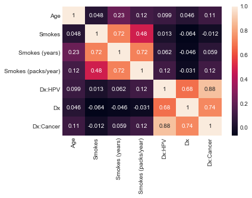

```python
sns.heatmap(smoke_data[['Age','Smokes','Smokes (years)', 'Smokes (packs/year)','Dx:HPV','Dx','Dx:Cancer']].corr(),annot=True)
```

### The habit of smoking and its duration, amount doesn’t have a significant correlation with having Cervical or another kind of cancer as expected.

```python
short_df['perception_severity'].corr(short_df['ca_cervix'])
```

```
-0.5082170123821567
```

```python
short_df['empowerment_desires'].corr(short_df['ca_cervix'])
```

```
-0.4588145734729115
```

```python
short_df['empowerment_abilities'].corr(short_df['ca_cervix'])
```

```
-0.5423604617024188
```

```python
short_df['motivation_willingness'].corr(short_df['ca_cervix'])
```

```
-0.42898927954064
```

```python
short_df['motivation_strength'].corr(short_df['ca_cervix'])
```

```
-0.4673242852337459
```

```python
short_df['perception_vulnerability'].corr(short_df['ca_cervix'])
```

```
-0.42310899882048053
```

```python
short_df['norm_fulfillment'].corr(short_df['ca_cervix'])
```

```
-0.4276738133309198
```

```python
short_df['empowerment_knowledge'].corr(short_df['ca_cervix'])
```

```
-0.4818141693439629
```

```python
short_df['socialSupport_emotionality'].corr(short_df['ca_cervix'])
```

```
-0.3919047702016485
```

```python
short_df['socialSupport_appreciation'].corr(short_df['ca_cervix'])
```

```
-0.31330721698660746
```

## Conclusion: Although smoking does not have much correlation (initial focus), there is evidence to support the claim that there is a moderate correlation between Cervical Cancer and some certain Risk Behaviors (Dx:HPV, empowerment_ability, perception_severity).

#### Resources:

- http://archive.ics.uci.edu/ml/datasets/Cervical+cancer+%28Risk+Factors%29#
- https://archive.ics.uci.edu/ml/datasets/Cervical+Cancer+Behavior+Risk#
- https://www.hindawi.com/journals/sp/2021/5540024/